# FML Assignment 4

Peter

2024-03-16

### Summary

The cluster analysis of 21 firms based on numerical variables (1 to 9) revealed distinct clusters using K-Means, DBSCAN, and Hierarchical Clustering techniques. K-Means with k=5 was chosen as the optimal solution due to its clear separation of clusters. Interpretation of clusters highlighted differences in market capitalization, volatility, profitability, and leverage. Non-clustering variables (10 to 12) revealed patterns in revenue growth and net profit margin across clusters. Naming clusters “Fast and Furious” and “Slow and steady” reflect their distinct traits and potential directions for further research.

```r
# Loading necessary packages
library(tidyverse)
library(factoextra)
library(fpc)
library(dbscan)
```

```r
library(stats)
library(ggplot2)
library(dendextend)
library(cluster)
```

```r
# Loading the data set and validating
pharma <- read.csv("./Pharmaceuticals.csv")
pharma <- na.omit(pharma)
head(pharma,2)
```

```
##   Symbol                Name Market_Cap Beta PE_Ratio  ROE  ROA Asset_Turnover
## 1    ABT Abbott Laboratories      68.44 0.32     24.7 26.4 11.8            0.7
## 2    AGN      Allergan, Inc.       7.58 0.41     82.5 12.9  5.5            0.9
##   Leverage Rev_Growth Net_Profit_Margin Median_Recommendation Location Exchange
## 1     0.42       7.54              16.1          Moderate Buy       US     NYSE
## 2     0.60       9.16               5.5          Moderate Buy   CANADA     NYSE
```

```r
tail(pharma,2)
```

```
##    Symbol                         Name Market_Cap Beta PE_Ratio  ROE  ROA
## 20    WPI Watson Pharmaceuticals, Inc.       3.26 0.24     18.4 10.2  6.8
## 21    WYE                        Wyeth      48.19 0.63     13.1 54.9 13.4
##    Asset_Turnover Leverage Rev_Growth Net_Profit_Margin Median_Recommendation
## 20            0.5     0.20      29.18              15.1         Moderate Sell
## 21            0.6     1.12       0.36              25.5                  Hold
##    Location Exchange
## 20       US     NYSE
## 21       US     NYSE
```

```r
t(t(names(pharma)))
```

```
##       [,1]
##  [1,] "Symbol"
##  [2,] "Name"
##  [3,] "Market_Cap"
##  [4,] "Beta"
##  [5,] "PE_Ratio"
##  [6,] "ROE"
##  [7,] "ROA"
##  [8,] "Asset_Turnover"
##  [9,] "Leverage"
## [10,] "Rev_Growth"
## [11,] "Net_Profit_Margin"
## [12,] "Median_Recommendation"
## [13,] "Location"
## [14,] "Exchange"
```

```r
dim(pharma)
```

```
## [1] 21 14
```

Selecting numerical variables (1 to 9) to cluster the 21 firms.

```r
row.names(pharma) <- pharma[,1]
cluster <- pharma[,3:11]
```

Scaling the data

```r
set.seed(24)
Scaled_pharma<-scale(cluster)
```

Performing Kmeans for random K values

```r
set.seed(24)
k_pharma_2<-kmeans(Scaled_pharma,centers = 2, nstart = 15)
k_pharma_4<-kmeans(Scaled_pharma,centers = 4, nstart = 15)
k_pharma_8<-kmeans(Scaled_pharma,centers = 8, nstart = 15)
plot_k_pharma_2<-fviz_cluster(k_pharma_2,data = Scaled_pharma) + ggtitle("K Means = 2") + theme_minimal()
plot_k_pharma_4<-fviz_cluster(k_pharma_4,data = Scaled_pharma) + ggtitle("K Means = 4") + theme_minimal()
plot_k_pharma_8<-fviz_cluster(k_pharma_8,data = Scaled_pharma) + ggtitle("K Means = 8") + theme_minimal()
```

Visual repersentation of K Values for 2, 4 and 8

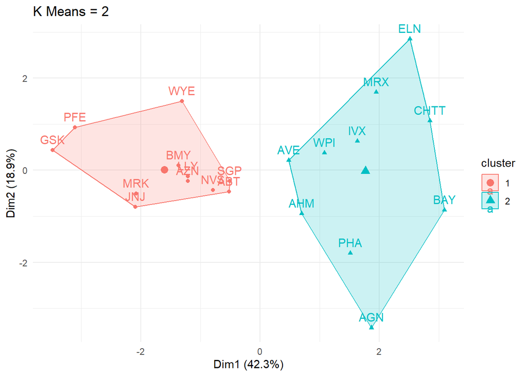

```r
plot_k_pharma_2
```

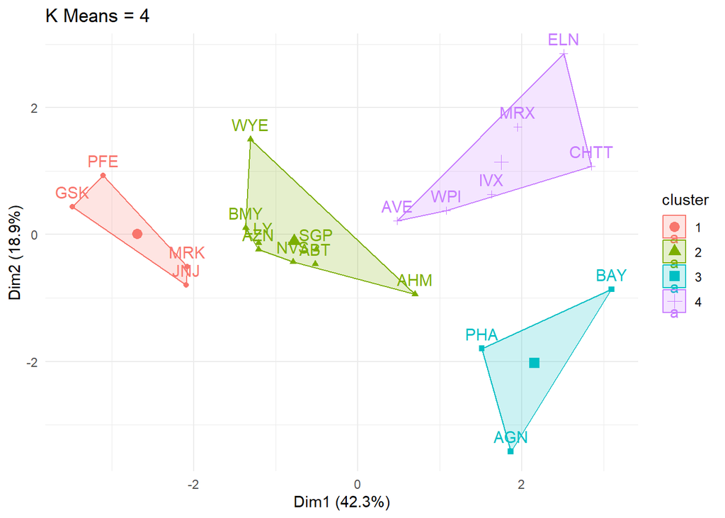

```r
plot_k_pharma_4
```